# Assignment 2 - Path Analysis

```r
#library(MVN)
library(lavaan)
library(haven)
library(semPlot)
```

```r
setwd('~/Google_Drive/courses/Structural_Equation_Modeling/assignments/assignment_02/')
getwd()
```

```
[1] "/Users/haroonpopal/Google_Drive/courses/Structural_Equation_Modeling/assignments/assignment_02"
```

# Replicating Path Analysis from Sexton et al., (2003)

[link to article](https://www.tandfonline.com/doi/abs/10.1080/16506070302321)

## Create a correlation matrix and a covariance matrix

```r
# Input information to create the matrix of information; notice that it is a square matrix with 1s on the diagonal
hw2_cor_mat <- matrix(c(1, .566, .534, .580, .414, .374, .665,
                        .566, 1, .487, .549, .583, .478, .535,
                        .534, .487, 1, .429, .273, .284, .569,
                        .580, .549, .429, 1, .492, .443, .554,
                        .414, .583, .273, .492, 1, .411, .546,
                        .374, .478, .284, .443, .411, 1, .332,
                        .665, .535, .569, .554, .546, .332, 1),
                    nrow = 7, ncol = 7)
# A numeric vector of the SDs of the variables
var_sds <- c(9.40, 23.34, 18.05, 9.11, 13.77, 15.20, 14.89)
# A list of the variable names for the matrix
var_names = c("NEO_N", "ASI_R", "IUS", "BAI", "IAS", "PI_WSUR", "PSWQ")
# Putting all of the information together to make a covariance matrix
hw2_cov <- cor2cov(hw2_cor_mat, var_sds, names = var_names)
hw2_cov
```

```
            NEO_N    ASI_R       IUS       BAI       IAS   PI_WSUR      PSWQ
NEO_N    88.36000 124.1781  90.60378  49.66772  53.58733  53.43712  93.07739
ASI_R   124.17814 544.7556 205.16677 116.73244 187.37142 169.57910 185.92994
IUS      90.60378 205.1668 325.80250  70.54283  67.85374  77.91824 152.92700
BAI      49.66772 116.7324  70.54283  82.99210  61.71879  61.34310  75.14894
IAS      53.58733 187.3714  67.85374  61.71879 189.61290  86.02394 111.94927
PI_WSUR  53.43712 169.5791  77.91824  61.34310  86.02394 231.04000  75.14090
PSWQ     93.07739 185.9299 152.92700  75.14894 111.94927  75.14090 221.71210
```

## Replicate regression analysis

I was having trouble replicating the entire hierarchical analysis, so I decided to just do one arm of the analysis.

```r
# Define the model of interest
hw2_m1 <- 'BAI ~ ASI_R + NEO_N + IUS
           ASI_R ~ NEO_N
           IUS ~ NEO_N'
# Estimate the model
hw2_m1_fit <- sem(hw2_m1, sample.cov = hw2_cov, sample.nobs = 91)
# Examine initial model fit information
hw2_m1_fit
```

```
lavaan 0.6-5 ended normally after 22 iterations

  Estimator                                         ML
  Optimization method                           NLMINB
  Number of free parameters                          8

  Number of observations                            91

Model Test User Model:

  Test statistic                                 6.629
  Degrees of freedom                                 1
  P-value (Chi-square)                           0.010
```

```r
# Examine more information
summary(hw2_m1_fit)
```

```
lavaan 0.6-5 ended normally after 22 iterations

  Estimator                                         ML
  Optimization method                           NLMINB
  Number of free parameters                          8

  Number of observations                            91

Model Test User Model:

  Test statistic                                 6.629
  Degrees of freedom                                 1
  P-value (Chi-square)                           0.010

Parameter Estimates:

  Information                                 Expected
  Information saturated (h1) model          Structured
  Standard errors                             Standard

Regressions:
                   Estimate  Std.Err  z-value  P(>|z|)
  BAI ~
    ASI_R             0.117    0.038    3.086    0.002
    NEO_N             0.351    0.106    3.299    0.001
    IUS               0.045    0.048    0.939    0.348
  ASI_R ~
    NEO_N             1.405    0.215    6.549    0.000
  IUS ~
    NEO_N             1.025    0.170    6.025    0.000

Variances:
                   Estimate  Std.Err  z-value  P(>|z|)
   .BAI              48.151    7.138    6.745    0.000
   .ASI_R           366.171   54.285    6.745    0.000
   .IUS             230.339   34.148    6.745    0.000
```

There was a failure to completely replicated the findings in Sexton et al. (2003). The betas of the replication analysis are very different from the betas in the hierarchical path analysis from the original paper. What is consistent, however, is the significant paths. Panic symptoms (BAI) is predicted by anxiety sensitivity (ASI_R) and neuroticism (NEO_N), but not by intolerance of uncertainty (IUS). This could be due to missing variance from the item level data for participants. The individual differences are not fully captured by the univariate standard deviation, nor the correlation matrix or resulting covariance matrix.

# Path Analysis on Observed Data

```r
## Load dataframe of raw data
hw2_df <- read.csv('../unrestricted_hspopal_9_9_2019_22_40_57.csv')
```

## Information about the dataset

This dataset is the Human Connectome Project data for healthy young adults. I will be looking at neuroticism from the NEO-PI, a measure of theory of mind, a measure of friendship, and a measure of angry affect.

# Estimate using FIML

```r
hw2_m2 <- 'NEOFAC_O ~ Social_Task_Perc_TOM + Friendship_Unadj + AngAffect_Unadj
           NEOFAC_N ~ Social_Task_Perc_TOM + Friendship_Unadj + AngAffect_Unadj
           Friendship_Unadj ~~ AngAffect_Unadj
           Friendship_Unadj ~~ Social_Task_Perc_TOM
           Social_Task_Perc_TOM ~~ AngAffect_Unadj'
# Estimation of FIML model
hw2_m2_fit <- sem(hw2_m2, hw2_df, missing = "fiml")
## Model Information FIML model
summary(hw2_m2_fit)
```

```
lavaan 0.6-5 ended normally after 95 iterations

  Estimator                                         ML
  Optimization method                           NLMINB
  Number of free parameters                         20

  Number of observations                          1206
  Number of missing patterns                         5

Model Test User Model:

  Test statistic                                 0.000
  Degrees of freedom                                 0

Parameter Estimates:

  Information                                 Observed
  Observed information based on                Hessian
  Standard errors                             Standard

Regressions:
                   Estimate  Std.Err  z-value  P(>|z|)
  NEOFAC_O ~
    Scl_Tsk_Pr_TOM    0.092    0.023    4.072    0.000
    Friendshp_Undj    0.046    0.021    2.236    0.025
    AngAffect_Undj    0.045    0.022    2.009    0.045
  NEOFAC_N ~
    Scl_Tsk_Pr_TOM   -0.034    0.023   -1.484    0.138
    Friendshp_Undj   -0.170    0.021   -8.183    0.000
    AngAffect_Undj    0.369    0.023   16.328    0.000

Covariances:
                          Estimate  Std.Err  z-value  P(>|z|)
  Friendship_Unadj ~~
    AngAffect_Undj         -22.128    2.295   -9.644    0.000
  Social_Task_Perc_TOM ~~
    Friendshp_Undj          -0.875    2.402   -0.365    0.715
    AngAffect_Undj          -0.522    2.237   -0.233    0.816
 .NEOFAC_O ~~
   .NEOFAC_N                 0.654    1.130    0.579    0.562

Intercepts:
                   Estimate  Std.Err  z-value  P(>|z|)
   .NEOFAC_O         19.204    2.045    9.392    0.000
   .NEOFAC_N          9.318    2.070    4.501    0.000
    Scl_Tsk_Pr_TOM   49.101    0.261  188.036    0.000
    Friendshp_Undj   50.199    0.262  191.282    0.000
    AngAffect_Undj   48.037    0.242  198.565    0.000

Variances:
                   Estimate  Std.Err  z-value  P(>|z|)
   .NEOFAC_O         38.533    1.578   24.424    0.000
   .NEOFAC_N         39.602    1.618   24.471    0.000
    Scl_Tsk_Pr_TOM   71.881    3.132   22.947    0.000
    Friendshp_Undj   82.999    3.382   24.545    0.000
    AngAffect_Undj   70.537    2.874   24.546    0.000
```

## Figure of model

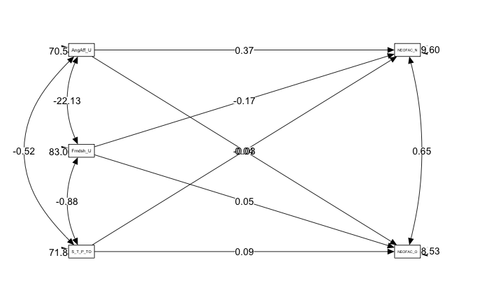

```r
semPaths(hw2_m2_fit, "path", whatLabels = "est",
         edge.label.cex = 1, rotation = 2, intercepts = FALSE, residuals = TRUE, curve = 1,
         curvature = 3, nCharNodes = 8, sizeMan = 6, sizeMan2 = 3, optimizeLatRes = TRUE, edge.color = "#000000")
```

# Estimate without using FIML

```r
hw2_m3 <- 'NEOFAC_O ~ Social_Task_Perc_TOM + Friendship_Unadj + AngAffect_Unadj
           NEOFAC_N ~ Social_Task_Perc_TOM + Friendship_Unadj + AngAffect_Unadj'
# Estimation of FIML model
hw2_m3_fit <- sem(hw2_m3, hw2_df)
## Model Information FIML model
summary(hw2_m3_fit)
```

```
lavaan 0.6-5 ended normally after 26 iterations

  Estimator                                         ML
  Optimization method                           NLMINB
  Number of free parameters                          9

                                                  Used       Total
  Number of observations                          1051        1206

Model Test User Model:

  Test statistic                                 0.000
  Degrees of freedom                                 0

Parameter Estimates:

  Information                                 Expected
  Information saturated (h1) model          Structured
  Standard errors                             Standard

Regressions:
                   Estimate  Std.Err  z-value  P(>|z|)
  NEOFAC_O ~
    Scl_Tsk_Pr_TOM    0.091    0.022    4.052    0.000
    Friendshp_Undj    0.041    0.022    1.858    0.063
    AngAffect_Undj    0.039    0.024    1.626    0.104
  NEOFAC_N ~
    Scl_Tsk_Pr_TOM   -0.033    0.023   -1.466    0.143
    Friendshp_Undj   -0.179    0.022   -8.005    0.000
    AngAffect_Undj    0.379    0.025   15.454    0.000

Covariances:
                   Estimate  Std.Err  z-value  P(>|z|)
 .NEOFAC_O ~~
   .NEOFAC_N          1.172    1.192    0.983    0.325

Variances:
                   Estimate  Std.Err  z-value  P(>|z|)
   .NEOFAC_O         37.894    1.653   22.924    0.000
   .NEOFAC_N         39.393    1.718   22.924    0.000
```

Running this analysis with FIML and without resulted in slightly different betas. Some predictors were also not significant when FIML was not done.

## Figure of model

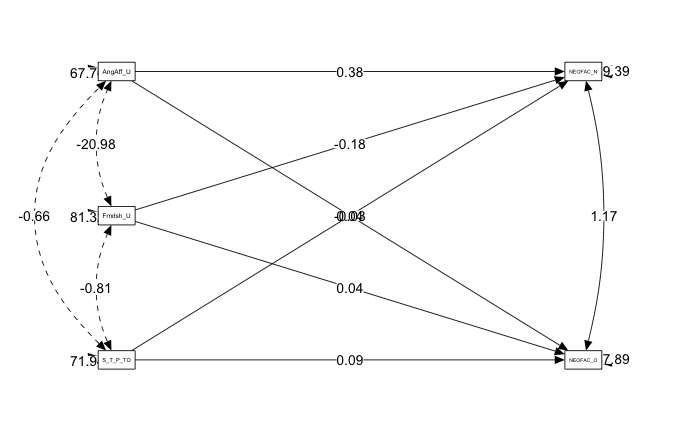

```r
semPaths(hw2_m3_fit, "path", whatLabels = "est",
         edge.label.cex = 1, rotation = 2, intercepts = FALSE, residuals = TRUE, curve = 1,
         curvature = 3, nCharNodes = 8, sizeMan = 6, sizeMan2 = 3, optimizeLatRes = TRUE, edge.color = "#000000")
```